# BIOS 611 HW1 Data visualisation (Chapter 3)

# Exercise 2

1. What do the empty cells in plot with `facet_grid(drv ~ cyl)` mean? How do they relate to this plot?

   ```r
   ggplot(data = mpg) +
     geom_point(mapping = aes(x = drv, y = cyl))
   ```

   Answer:

   The following plot is what is being referred to in the question as the plot with `facet_grid(drv ~ cyl)`.

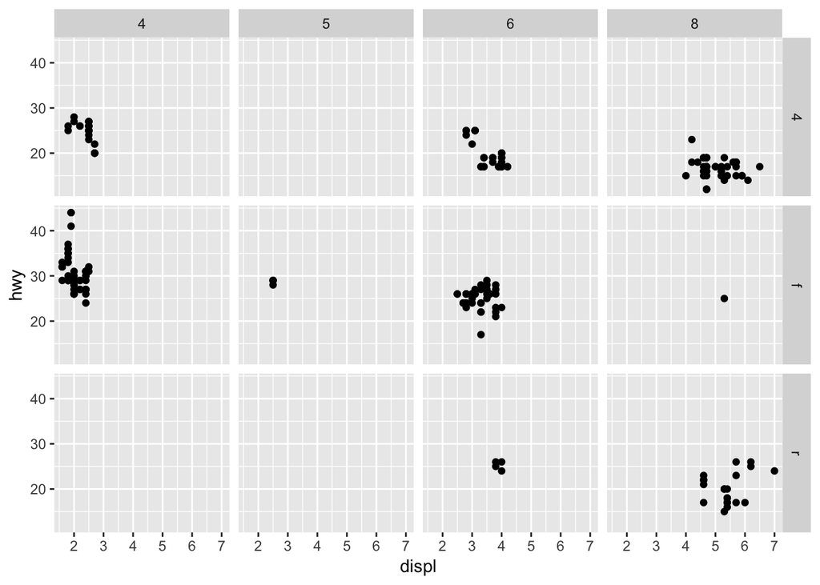

   ```r
   ggplot(data = mpg) +
     geom_point(mapping = aes(x = displ, y = hwy)) +
     facet_grid(drv ~ cyl)
   ```

   And the question is asking us to compare to the following plot:

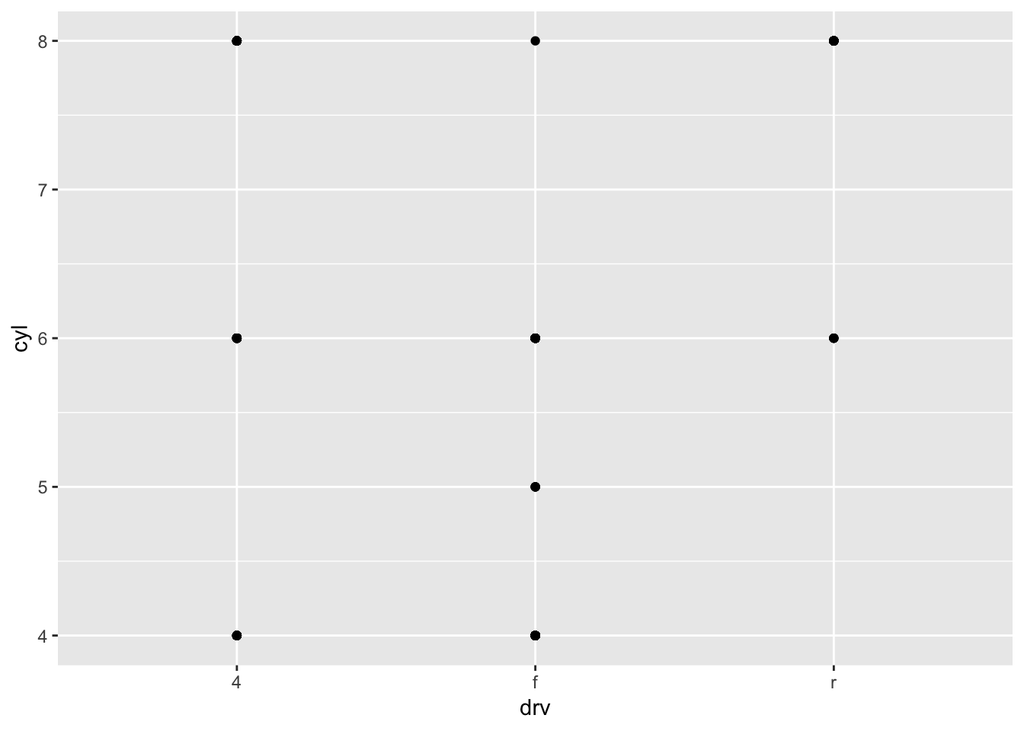

   ```r
   ggplot(data = mpg) +
     geom_point(mapping = aes(x = drv, y = cyl))
   ```

   The empty cells in the plot with `facet_grid(drv ~ cyl)` mean that there are no cars in the dataset with
   - 4 cylinders and rear wheel drive
   - 5 cylinders and 4 wheel drive
   - 5 cylinders and rear wheel drive

   Also, the second plot shows that there are no cars with 7 cylinders.
2. What plots does the following code make? What does `.` do?

   ```r
   ggplot(data = mpg) +
     geom_point(mapping = aes(x = displ, y = hwy)) +
     facet_grid(drv ~ .)

   ggplot(data = mpg) +
     geom_point(mapping = aes(x = displ, y = hwy)) +
     facet_grid(. ~ cyl)
   ```

   Answer:

   When the `.` is on the right side of `~`, this indicates to have the variables on the left side of `~` be the rows:

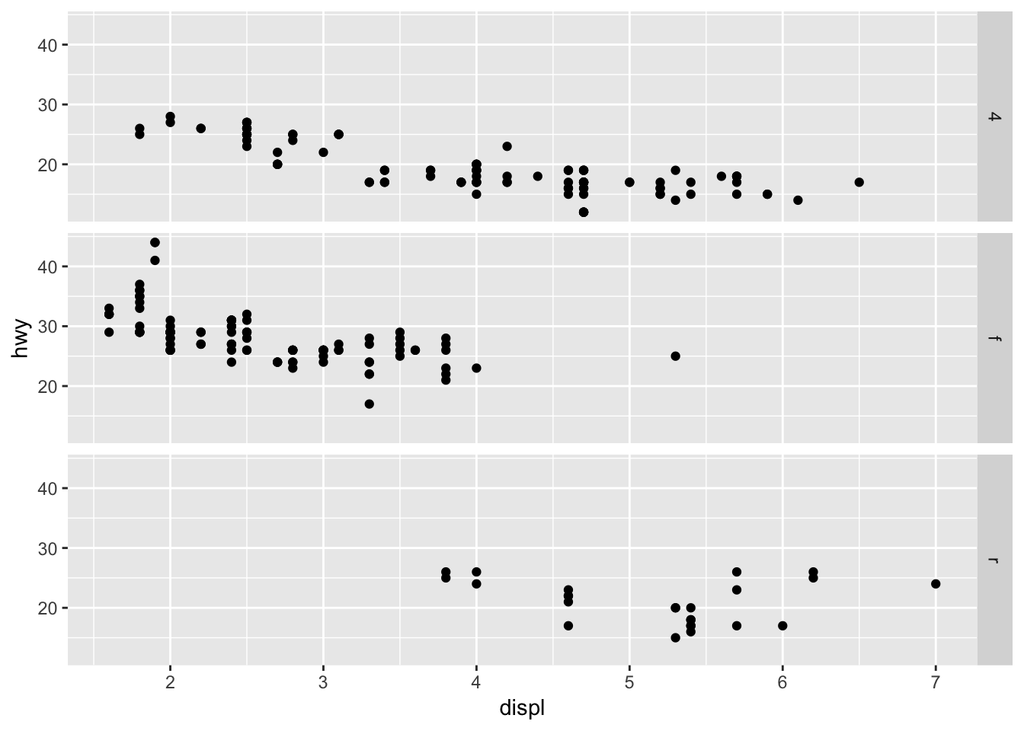

   ```r
   ggplot(data = mpg) +
     geom_point(mapping = aes(x = displ, y = hwy)) +
     facet_grid(drv ~ .)
   ```

   When the `.` is on the left side of `~`, this indicates to have the variables on the right side of `~` be the columns:

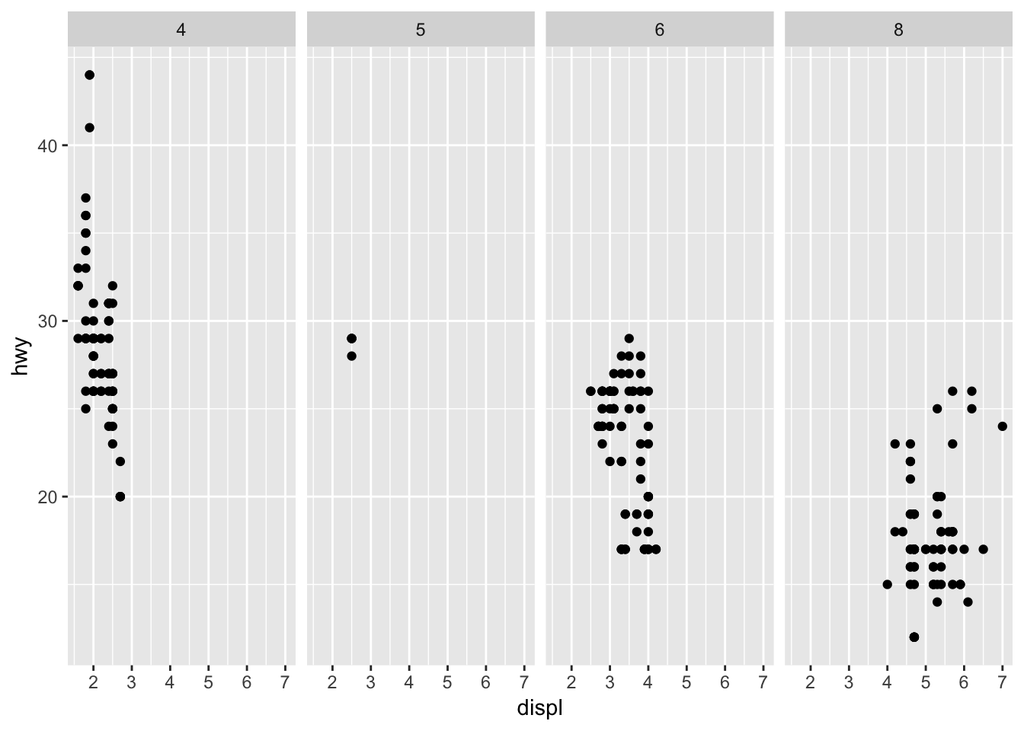

   ```r
   ggplot(data = mpg) +
     geom_point(mapping = aes(x = displ, y = hwy)) +
     facet_grid(. ~ cyl)
   ```

3. Take the first faceted plot in this section:

   ```r
   ggplot(data = mpg) +
     geom_point(mapping = aes(x = displ, y = hwy)) +
     facet_wrap(~ class, nrow = 2)
   ```

   What are the advantages to using faceting instead of the colour aesthetic? What are the disadvantages? How might the balance change if you had a larger dataset?

   Answer:

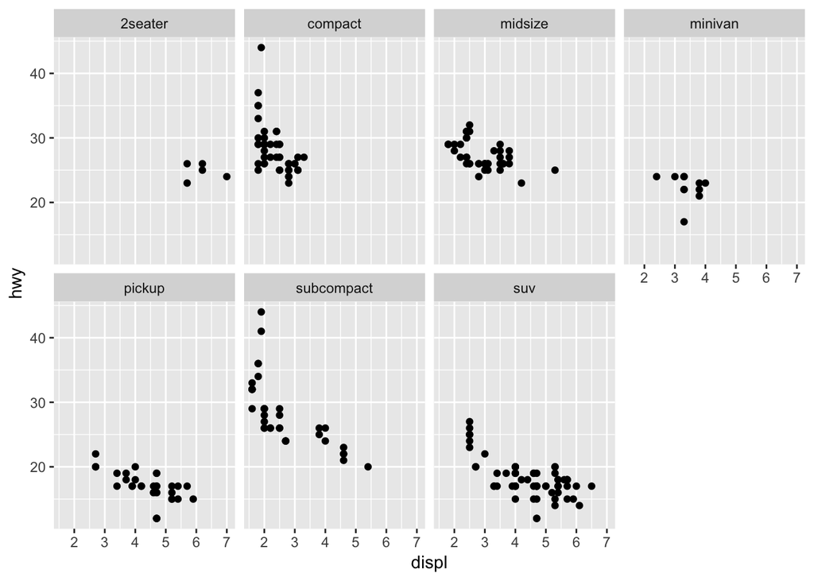

   ```r
   ggplot(data = mpg) +
     geom_point(mapping = aes(x = displ, y = hwy)) +
     facet_wrap(~ class, nrow = 2)
   ```